# Assignment4

Swetha Narayanan

10/18/2018

## Problem Statement

In this project, we want to use text mining techniques, such as sentiment analysis, text classification and topic modelling to understand content in a text dataset

## Set seed and Load libraries

```r
set.seed(5152)
library(parallel)
library(doParallel)
library(tm)
library(caret)
library(plyr)
library(dplyr)
library(purrr)
library(stringr)
library(jsonlite)
```

```r
library(corrplot)
library(topicmodels)
library(tidytext)
library(tibble)
library(text2vec)
library(tidyr)
library(performanceEstimation)
library(lsa)
library(RColorBrewer)
library(gplots)
library(ranger)
require("tm.lexicon.GeneralInquirer")
```

## Data load

```r
ted_main <- read.csv("ted_main.csv")
nrow(ted_main)
```

```
## [1] 2550
```

```r
transcripts <- read.csv("transcripts.csv")
nrow(transcripts)
```

```
## [1] 2467
```

```r
transcripts<- unique(transcripts)
nrow(transcripts)
```

```
## [1] 2464
```

```r
transcripts <- transcripts[,c("transcript","url")]

ted_merged <- merge(ted_main, transcripts, by = "url")
nrow(ted_merged)
```

```
## [1] 2464
```

```r
ted_merged$transcript <- iconv(ted_merged$transcript,"WINDOWS-1252","UTF-8")
ted_merged$id <- seq.int(nrow(ted_merged)) #id to maintain sequence
```

## Enable parallel analysis

```r
# Create cluster to run R in parallel; best to use total number of CPU - 1
cl <- makePSOCKcluster(detectCores() - 1)

# Allow libraries such as doParallel and tm to access the cluster
registerDoParallel(cl)
tm_parLapply_engine(cl)
#gc() - perform gc from time to time
```

## Task #1 : Data pre-processing of textual transcript data

```r
transcript_corpus <- VCorpus(VectorSource(ted_merged$transcript))
transcript_corpus <- tm_map(transcript_corpus, content_transformer(tolower))
transcript_corpus <- tm_map(transcript_corpus, content_transformer(gsub), pattern="\\W",replace=" ") # remove emojis
transcript_corpus <- tm_map(transcript_corpus, removeNumbers) # remove numbers
transcript_corpus <- tm_map(transcript_corpus, removeWords, stopwords()) # remove stop words
transcript_corpus <- tm_map(transcript_corpus, removePunctuation) # remove punctuation
transcript_corpus <- tm_map(transcript_corpus, stemDocument)
conv2space <- content_transformer(function (x , pattern ) gsub(pattern, " ", x))
transcript_corpus <- tm_map(transcript_corpus, conv2space, "/")
transcript_corpus <- tm_map(transcript_corpus, conv2space, "@")
transcript_corpus <- tm_map(transcript_corpus, conv2space, "!")
transcript_corpus <- tm_map(transcript_corpus, stripWhitespace) # eliminate unneeded whitespace
```

## Task #2 :Text Analysis using dictionary Approach

We can determine the emotions that are associated with the talks by counting the occurrences of the emotions terms. Then we create heatmap with one axis as emotions and the other as the talks. The colour of the heatmap will show the count of the emotions. We can expect it to be very dense and you might not want to show the label for the talks. This visualisation basically helps us to understand what kind of emotions are in the talks.

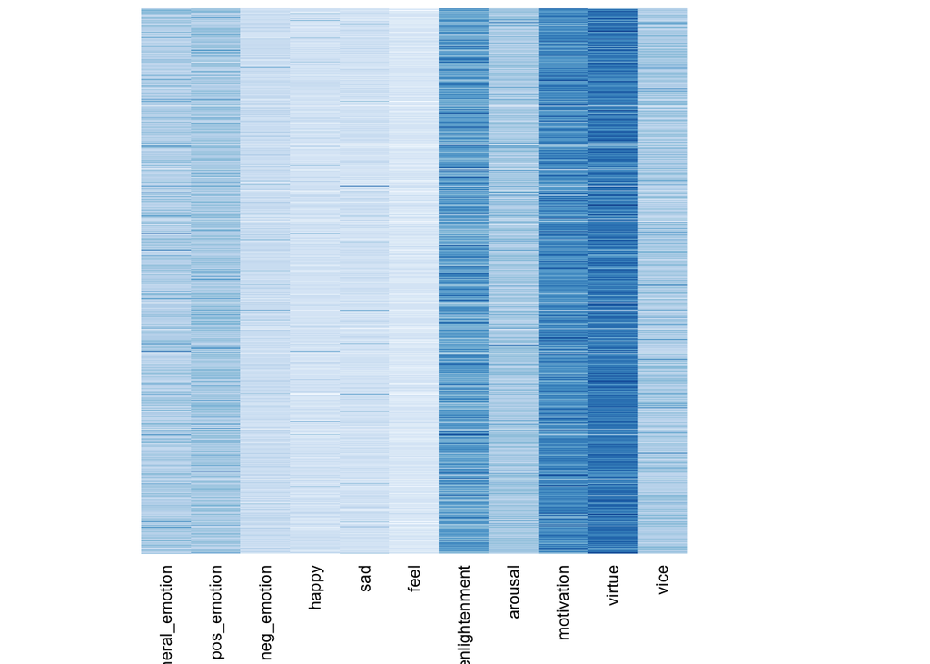

```r
#Approach : using tm_term_score
tf_dtm = DocumentTermMatrix(transcript_corpus, control = list(weighting = weightTf))
freq_terms <- findFreqTerms(tf_dtm, lowfreq = 50)
tf_dtm <- DocumentTermMatrix(transcript_corpus, control = list(dictionary = freq_terms, weighting = weightTf))

get_specific_emotion_score <- function(tf_dtm, emotion_words, emotion_name )
{
  emotion_scores=tm_term_score(tf_dtm, emotion_words)
  emotion_scores_df <- tbl_df(emotion_scores) %>% rownames_to_column %>% rename(id = rowname) %>% rename(emotion = value)
  emotion_scores_df$id <- as.numeric(emotion_scores_df$id)
  colnames(emotion_scores_df) <- c("id",emotion_name)
  return(emotion_scores_df)
}
get_emotions_scores <- function(tf_dtm)
{
  pleasure_scores_df <- get_specific_emotion_score(tf_dtm, terms_in_General_Inquirer_categories("Pleasur") , "happy")
  pain_scores_df <- get_specific_emotion_score(tf_dtm, terms_in_General_Inquirer_categories("Pain"), "sad")
  feel_scores_df <- get_specific_emotion_score(tf_dtm, terms_in_General_Inquirer_categories("Feel"), "feel")
  enlightened_scores_sf <- get_specific_emotion_score(tf_dtm, terms_in_General_Inquirer_categories("EnlGain"), "enlightenment")
  arousal_scores_df <- get_specific_emotion_score(tf_dtm, terms_in_General_Inquirer_categories("Arousal"), "arousal")
  motivation_scores_df <- get_specific_emotion_score(tf_dtm, terms_in_General_Inquirer_categories("Means"), "motivation")
  virtue_scores_df <- get_specific_emotion_score(tf_dtm, terms_in_General_Inquirer_categories("Virtue"), "virtue")
  vice_scores_df <- get_specific_emotion_score(tf_dtm, terms_in_General_Inquirer_categories("Vice"), "vice")
  general_emot_scores_df <- get_specific_emotion_score(tf_dtm, terms_in_General_Inquirer_categories("EMOT"), "general_emotion")
  positive_emot_scores_df <- get_specific_emotion_score(tf_dtm, terms_in_General_Inquirer_categories("PosAff"), "pos_emotion")
  negative_emot_scores_df <- get_specific_emotion_score(tf_dtm, terms_in_General_Inquirer_categories("NegAff"), "neg_emotion")

  emotions_scores_df <- list(general_emot_scores_df, positive_emot_scores_df, negative_emot_scores_df, pleasure_scores_df, pain_scores_df, feel_scores_df, enlightened_scores_sf, arousal_scores_df, motivation_scores_df, virtue_scores_df, vice_scores_df) %>% reduce(full_join, by = "id")

  return(emotions_scores_df)
}

emotions_scores_df <- get_emotions_scores(tf_dtm)
emotions_scores_df <- dplyr::select(emotions_scores_df, -id)
heatmap(as.matrix(emotions_scores_df), Rowv = NA, Colv = NA, cexCol=0.9, labRow=paste(""), col = colorRampPalette(brewer.pal(8, "Blues"))(20))
```

## Task #3 :Text Classification

We perform a multi-class classification on the ratings on the talks to predict how the talks will likely to get what rating from the viewers. We can evaluate the model based on metrics such as micro and macro F1 and describe what are the common ratings that are misclassified in your model Notes: 1. We will need to replace single quote with double for ratings column before using jsonlite to parse it. 2. We use the rating with the highest count as the label for each talk. In other words, we are predicting a categorical variable, NOT a numerical variable such as average rating.

```r
#Find Main_Rating associated with each talk
for (i in 1:nrow(ted_merged))
{
  df <- fromJSON(str_replace_all(ted_merged$rating[i],"'",'"'))
  main_rating <- df[which.max(df$count), "name"]
  ted_merged[i, "Main_Rating"] = main_rating
}

#Convert to document term matrix using TF-IDF weighting
dtm_control <- list(weighting = function(x) weightTfIdf(x, normalize = FALSE))
transcript_dtm <- DocumentTermMatrix(transcript_corpus, control = dtm_control)
features_df <- tbl_df(as.matrix(transcript_dtm))
nzv_columns <- nearZeroVar(features_df)
features_df <- features_df[, -nzv_columns]

#Split into training and test
train_idx <- sample(nrow(features_df) * 0.7)
train_features_df <- features_df[train_idx,]
test_features_df <- features_df[-train_idx,]
train_main_rating <- as.data.frame(ted_merged[train_idx,"Main_Rating"])
colnames(train_main_rating) <- c("Main_Rating")
test_main_rating <- as.data.frame(ted_merged[-train_idx,"Main_Rating"])
colnames(test_main_rating) <- c("Main_Rating")

#Using Random Forest Ranger - Faster implementation of RF
ctrl <- trainControl(method = 'cv', number = 3,verboseIter = TRUE)
rf_mod <- train(x = train_features_df,
                y = as.factor(train_main_rating$Main_Rating),
                method = "ranger",
                trControl = ctrl,
                tuneGrid = data.frame(mtry = floor(sqrt(dim(train_features_df)[2])),
                                      splitrule = "gini",
                                      min.node.size = 1))
train_pred <- predict(rf_mod, train_features_df)
test_pred <- predict(rf_mod, test_features_df)
train_cm = as.matrix(table(Actual=train_main_rating$Main_Rating, Predicted=train_pred))
train_cm
```

```
##               Predicted
## Actual         Beautiful Confusing Courageous Fascinating Funny
##   Beautiful          100         0          0           0     0
##   Confusing            0         1          0           0     0
##   Courageous           0         0         59           0     0
##   Fascinating          1         0          0         179     0
##   Funny                0         0          0           0   107
##   Informative          0         0          0           0     0
##   Ingenious            0         0          0           0     0
##   Inspiring            0         0          0           0     0
##   Jaw-dropping         1         0          0           0     0
##   Longwinded           0         0          0           0     0
##   Obnoxious            0         0          0           0     0
##   OK                   0         0          0           0     0
##   Persuasive           0         0          0           0     0
##   Unconvincing         0         0          0           0     0
##               Predicted
## Actual         Informative Ingenious Inspiring Jaw-dropping Longwinded
##   Beautiful              0         0         1            0          0
##   Confusing              0         0         0            0          0
##   Courageous             0         0         0            0          0
##   Fascinating            0         0         0            0          0
##   Funny                  0         0         1            0          0
##   Informative          480         0         3            0          0
##   Ingenious              0        79         1            0          0
##   Inspiring              0         0       597            0          0
##   Jaw-dropping           0         0         0           30          0
##   Longwinded             0         0         0            0          7
##   Obnoxious              0         0         0            0          0
##   OK                     0         0         0            0          0
##   Persuasive             0         0         0            0          0
##   Unconvincing           0         0         0            0          0
##               Predicted
## Actual         Obnoxious  OK Persuasive Unconvincing
##   Beautiful            0   0          0            0
##   Confusing            0   0          0            0
##   Courageous           0   0          0            0
##   Fascinating          0   0          0            0
##   Funny                0   0          0            0
##   Informative          0   0          0            0
##   Ingenious            0   0          0            0
##   Inspiring            0   0          0            0
##   Jaw-dropping         0   0          0            0
##   Longwinded           0   0          0            0
##   Obnoxious            2   0          0            0
##   OK                   0   4          0            0
##   Persuasive           0   0         58            0
##   Unconvincing         0   0          0           13
```

```r
cm = as.matrix(table(Actual=test_main_rating$Main_Rating, Predicted=test_pred))
cm
```

```
##               Predicted
## Actual         Beautiful Confusing Courageous Fascinating Funny
##   Beautiful           11         0          0           0     0
##   Confusing            0         0          0           0     0
##   Courageous           0         0          0           0     0
##   Fascinating          0         0          0           2     0
##   Funny                2         0          0           0     0
##   Informative          0         0          0           0     0
##   Ingenious            2         0          0           0     0
##   Inspiring            0         0          0           0     0
##   Jaw-dropping         2         0          0           0     0
##   Longwinded           0         0          0           0     0
##   Obnoxious            0         0          0           0     0
##   OK                   1         0          0           0     0
##   Persuasive           0         0          0           0     0
##   Unconvincing         0         0          0           0     0
##               Predicted
## Actual         Informative Ingenious Inspiring Jaw-dropping Longwinded
##   Beautiful              3         0        27            0          0
##   Confusing              0         0         1            0          0
##   Courageous             1         0        22            0          0
##   Fascinating           35         0        34            0          0
##   Funny                 10         0        38            0          0
##   Informative          149         0        79            0          0
##   Ingenious             16         0         3            0          0
##   Inspiring             28         0       224            0          0
##   Jaw-dropping          11         0         5            0          0
##   Longwinded             0         0         1            0          0
##   Obnoxious              1         0         0            0          0
##   OK                     1         0         0            0          0
##   Persuasive            12         0         9            0          0
##   Unconvincing           9         0         1            0          0
##               Predicted
## Actual         Obnoxious  OK Persuasive Unconvincing
##   Beautiful            0   0          0            0
##   Confusing            0   0          0            0
##   Courageous           0   0          0            0
##   Fascinating          0   0          0            0
##   Funny                0   0          0            0
##   Informative          0   0          0            0
##   Ingenious            0   0          0            0
##   Inspiring            0   0          0            0
##   Jaw-dropping         0   0          0            0
##   Longwinded           0   0          0            0
##   Obnoxious            0   0          0            0
##   OK                   0   0          0            0
##   Persuasive           0   0          0            0
##   Unconvincing         0   0          0            0
```

```r
#macroF1
n_instances = sum(cm)
n_classes = nrow(cm) # number of classes
correctlyClassified = diag(cm) # number of correctly classified instances per class
correctlyClassifiedTbl <- tbl_df(correctlyClassified) %>% rownames_to_column
rowsums = apply(cm, 1, sum) # number of instances per class
colsums = apply(cm, 2, sum) # number of predictions per class
accuracy = sum(correctlyClassified) / n_instances
precision = correctlyClassified / colsums
recall = correctlyClassified / rowsums
f1 = 2 * precision * recall / (precision + recall)
macroPrecision = mean(na.exclude(precision))
macroRecall = mean(recall)
macroF1 = mean(na.exclude(f1))
print(data.frame(unique(accuracy), macroPrecision, macroRecall, macroF1))
```

```
##   unique.accuracy. macroPrecision macroRecall  macroF1
## 1        0.5216216      0.6638677   0.1313471 0.415656
```

```r
#oneVsAll matrix
oneVsAll = lapply(1 : n_classes,
                        function(i){
                          v = c(cm[i,i],
                                rowsums[i] - cm[i,i],
                                colsums[i] - cm[i,i],
                                n_instances-rowsums[i] - colsums[i] + cm[i,i]);
                          return(matrix(v, nrow = 2, byrow = T))})

#microF1
s = matrix(0, nrow = 2, ncol = 2)
for(i in 1 : n_classes){s = s + oneVsAll[[i]]}
s
```

```
##      [,1] [,2]
## [1,]  386  354
## [2,]  354 9266
```

```r
avgAccuracy = sum(diag(s)) / sum(s)
print(avgAccuracy)
```

```
## [1] 0.9316602
```

```r
microF1 = (diag(s) / apply(s,1, sum))[1]
microF1
```

```
## [1] 0.5216216
```

```r
#Commonly misclassified ratings
ratingToMisclassRate = data.frame(rating=sort(unique(test_main_rating$Main_Rating)))
getMisClassRate = function(cm){
  TP <- cm[2, 2]
  TN <- cm[1, 1]
  FP <- cm[2, 1]
  FN <- cm[1, 2]
  accuracy <- (TP + TN) / (TP + TN + FP + FN)
  return(1-accuracy)
}
for(i in 1 : nrow(ratingToMisclassRate))
{
  ratingToMisclassRate[i,"misclass_rate"] <- getMisClassRate(oneVsAll[[i]])
}
ratingToMisclassRate <- ratingToMisclassRate[order(-ratingToMisclassRate$misclass_rate),]
ratingToMisclassRate[1:3,]
```

```
##        rating misclass_rate
## 8   Inspiring    0.33513514
## 6 Informative    0.27837838
## 4 Fascinating    0.09324324
```

```r
#Automatic way to get Micro F1
classificationMetrics(test_main_rating$Main_Rating, test_pred)
```

```
##       acc       err    microF    macroF  macroRec macroPrec
## 0.5216216 0.4783784 0.5216216       NaN 0.1313471       NaN
```